# JASA_Realdata_Gastrectomy

Ziyi Wang

2026-03-16

# Real data

## Gastrectomy - The first real data in paper

### Load Packages/Functions

```r
suppressPackageStartupMessages({
  library(knitr)
  library(locfdr)
  library(CATMicrobiome)
  library(admix)
  library(mvtnorm)
  library(mixtools)
  library(devtools)
  library(KScorrect)
  library(mclust)
  library(adaptMT)
  library(AdaPTGMM)
  library(splines2)
  library(splines)
  library(dplyr)
  library(ggplot2)
  library(tidyr)
  library(coin)
  library(ggrepel)
  library(viridisLite)
  library(IHW)
  library(FDRreg)
  library(OrderShapeEM)
  library(chai)
})
```

### Load the data and pre-processing the data

Note: Note: The pro-processing part and model fitting chunk could be time-consuming. We saved the processed data together with the organized results after fitting the models. When knitting this HTML file, we loaded the **Gastrectomy_env.RData** file directly and generated the plots from it.

However, for verification or reproducibility, you can also run each pre-processing chunk and/or model-fitting chunk one by one, while skiping the chunk that loads the .RData file. This should produce the same results.

```r
# Load the data
mtb <- read.delim("./Erawijantari/mtb.tsv", header = TRUE, stringsAsFactors = FALSE, row.names = 1)

genera_counts <- read.delim("./Erawijantari/genera.counts.tsv", header = TRUE, stringsAsFactors = FALSE, row.names = 1)

metadata <- read.delim("./Erawijantari/metadata.tsv", header = TRUE, stringsAsFactors = FALSE)

table(metadata$Study.Group)

# Filter out the 'low abundance' across all subjects
# Keep genera that are non-zero in at least 10% of subjects
present_counts <- colSums(genera_counts > 0)
genera_counts_filtered <- genera_counts[, present_counts >= (nrow(genera_counts) * 0.1)] # 96 x 5163

# Get the abundance table - genera_abun
row_sums <- rowSums(genera_counts_filtered)
genera_abun <- sweep(genera_counts_filtered, 1, row_sums, FUN="/") # 96 x 5163

# Re-order the metadata to match the order of genera.
metadata_reorder <- metadata[match(rownames(genera_abun), metadata$Subject), ]

# Get the outcome - outcome
outcome <- as.factor(metadata_reorder$Study.Group)
```

### Generating the p-value/z-value for each genera

```r
# p-value/z-value
compute_pz_wilcox <- function(t_abun, outcome) {
  stopifnot(nrow(t_abun) == length(outcome))

  p_z_values <- sapply(colnames(t_abun), function(feature) {
    features <- t_abun[, feature, drop = FALSE]
    wilcox <- coin::wilcox_test(features[, 1] ~ outcome)

    c(
      p_value = as.numeric(coin::pvalue(wilcox)),
      z_value = as.numeric(coin::statistic(wilcox))
    )
  }, simplify = "matrix")
  p_z_values <- as.data.frame(t(p_z_values))
  p_z_values$feature <- rownames(p_z_values)
  rownames(p_z_values) <- NULL

  return(p_z_values)
}

p_z_values <- compute_pz_wilcox(genera_abun, outcome)
p_value <- p_z_values[,1]
z_value <- p_z_values[,2]
```

### Generating the side information - Canonical Correlation between genera relative abundance table and top 50 metabolomes

```r
######################## Metabolite ##############################
# Filter out the 'low abundance' metabolites
# Keep metabolites that are non-zero in at least 50% of subjects
present_counts <- colSums(mtb > 0)
mtb_filtered <- mtb[, present_counts >= (nrow(mtb) * 0.5)]
dim(mtb_filtered)
# 96 x 144

# Get top 50 'importance' of metabolites
mtb_norm <- mtb_filtered / rowSums(mtb_filtered)
metabolite_means <- colMeans(mtb_norm, na.rm = TRUE)
top50_metabolites <- names(sort(metabolite_means, decreasing = TRUE))[1:50]
mtb_top50 <- mtb_norm[, top50_metabolites]


# Check the order
# making sure that rownames of meta and of abun are matching
table(rownames(genera_abun) == rownames(mtb_top50))
table(rownames(genera_abun) == metadata_reorder$Subject)


################# Canonical Correlation #####################
cancor <- numeric(ncol(genera_abun))
for (i in 1:ncol(genera_abun)) {
  temp <- cancor(genera_abun[, i], mtb_top50)
  cancor[i] <- temp$cor
}
```

##### Load the processed data

The processed data included: - genera_abun: the relative abundance table of this Gastrectomy dataset at genera level - outcome: the outcome (gastrectomy or control) of this dataset  
- z_value: the z-statistics from wilcoxon text of each genera between gastrectomy vs control - p_value: the p-value calculated from z-statistics with two-sided - mtb_top50: the top 50 metabolomes - cancor: the Canonical Correlation coefficient of each genera

```r
load("./chai_env/Gastrectomy_env.RData")
```

##### Explore the data

```r
# alpha diversity
alpha_df <- tibble(
  sample = rownames(genera_abun),
  group = outcome,
  shannon = vegan::diversity(genera_abun, index = "shannon"),
  simpson = vegan::diversity(genera_abun, index = "simpson")
)

alpha_df$group <- factor(alpha_df$group, levels = c("Gastrectomy", "Healthy"))

cols <- c("Gastrectomy" = "#C8A100",
          "Healthy" = "#2C7FB8")

a_p <- wilcox.test(shannon ~ group, data = alpha_df)$p.value
a_lab <- sprintf("p-value = %.3g", a_p)


pa <- ggplot(alpha_df, aes(x = group, y = shannon, fill = group)) +
  geom_violin(trim = FALSE, alpha = 0.25) +
  geom_jitter(aes(color = group), width = 0.15, alpha = 0.6) +
  scale_fill_manual(values = cols) +
  scale_color_manual(values = cols) +
  labs(x = NULL, y = "Shannon", title = "Alpha diversity (Shannon)") +
  annotate("text",
           x = 1.5, y = max(alpha_df$shannon, na.rm = TRUE)*1.2,
           label = a_lab,
           size = 4, color = "black") +
  theme_bw() +
  theme(legend.position = "none")


# beta diversity
bc <- vegan::vegdist(genera_abun, method = "bray")

# PCoA
pcoa_res <- ape::pcoa(bc)
coords <- as.data.frame(pcoa_res$vectors[, 1:2, drop = FALSE])
colnames(coords) <- c("PCoA1", "PCoA2")
coords$sample <- rownames(coords)
coords$group <- outcome

# variance explained
rel_eig <- pcoa_res$values$Relative_eig
ve1 <- round(100*rel_eig[1], 1)
ve2 <- round(100*rel_eig[2], 1)

# PERMANVOA
ad <- adonis2(bc ~ outcome, permutations = 9999)

ad_r2 <- ad$R2[1]
ad_p <- ad$`Pr(>F)`[1]
ad_lab <- sprintf("PERMANOVA: R2 = %.3f, p = %.3g", ad_r2, ad_p)

coords$group <- factor(coords$group, levels = c("Gastrectomy", "Healthy"))

ppcoa <- ggplot(coords, aes(x = PCoA1, y = PCoA2)) +
  geom_point(aes(color = group), size = 2.5, alpha = 0.85) +
  stat_ellipse(aes(color = group, fill = group),
               level = 0.95, type = "t", linewidth = 1) +
  annotate("text",
           x = min(coords$PCoA1, na.rm = TRUE),
           y = max(coords$PCoA2, na.rm = TRUE),
           label = ad_lab,
           hjust = 0, vjust = 1,
           size = 4, color = "black") +
  scale_color_manual(values = cols) +
  scale_fill_manual(values = cols) +
  labs(
    title = "PCoA on Bray-Curtis distance",
    x = paste0("PCoA1 (", ve1, "%)"),
    y = paste0("PCoA2 (", ve2, "%)")
  ) +
  theme_bw()
library(patchwork)
p_ab <- pa + ppcoa +
  plot_layout(ncol = 2, widths = c(1, 1.2)) +
  plot_annotation(tag_levels = "A")
```

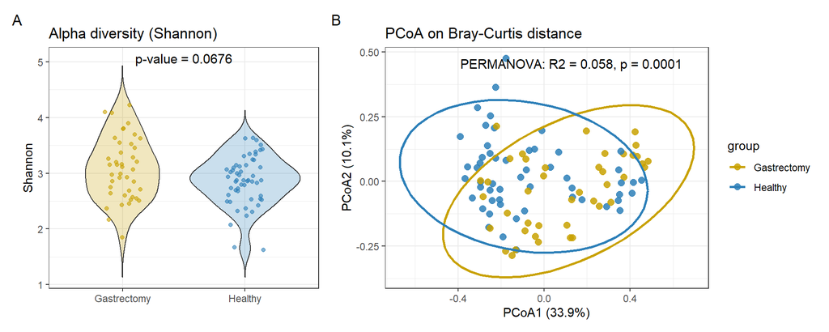

```r
p_ab
```

##### Fit the models

```r
q_levels <- seq(0.01, 0.10, by = 0.01)

# chai
set.seed(123)
chai_cca <- chai(z_value, as.matrix(cancor, ncol = 1), B = 100)
chai_rejs <- sapply(q_levels, function(q) {
  length(clfdrselect(chai_cca$clFDR, q, 1))
})

# Adapt_glm
x <- data.frame(cancor)
formula <- c(paste0("ns(cancor, df = ",2:8,")"))
glm_ns <- adapt_glm(x, pvals = p_value, alphas=q_levels,
                    pi_formulas = formula, mu_formulas = formula)
adapt_glm_ns_rej <- glm_ns$nrejs[1:10]

# Adapt_gmm_p
gmm_ns_p <- adapt_gmm(x, pvals = p_value,  alphas=q_levels,
                      beta_formulas = formula)
adapt_gmm_p_ns_rej <- gmm_ns_p$nrejs[1:10]

# Adapt_gmm_z
gmm_ns_z <- adapt_gmm(x, z = z_value, alphas=q_levels,
                      beta_formulas = formula, testing = "two_sided")
adapt_gmm_z_ns_rej <- gmm_ns_z$nrejs[1:10]

# OrderShapeEM
orderfdr <- OrderShapeEM(pvals = p_value, order.var = cancor,
                         OrderShapeEM.control(trace = TRUE))
ordershapeem_rejs <- sapply(q_levels, function(q) {
  sum(orderfdr$fdr <= q)
})

# FDRreg
set.seed(123)
fdr_theo <- FDRreg(z_value, as.matrix(cancor), nulltype = 'theoretical')
rdrreg_rejs <- sapply(q_levels, function(q) {
  length(which(fdr_theo$FDR <= q))
})

# IHW
############### Careful on running IHW!!!!!!
# ihw_rejs <- sapply(q_levels, function(q) {
#   ihw <- ihw(pvalues = p_value, covariates = cancor, alpha = q, nbins = 5)
#   rejections(ihw)
# })

ihw_01 <- ihw(pvalues = p_value, covariates = cancor, alpha = 0.01)
ihw_02 <- ihw(pvalues = p_value, covariates = cancor, alpha = 0.02)
ihw_03 <- ihw(pvalues = p_value, covariates = cancor, alpha = 0.03)
ihw_04 <- ihw(pvalues = p_value, covariates = cancor, alpha = 0.04)
ihw_05 <- ihw(pvalues = p_value, covariates = cancor, alpha = 0.05)
ihw_06 <- ihw(pvalues = p_value, covariates = cancor, alpha = 0.06)
ihw_07 <- ihw(pvalues = p_value, covariates = cancor, alpha = 0.07)
ihw_08 <- ihw(pvalues = p_value, covariates = cancor, alpha = 0.08)
ihw_09 <- ihw(pvalues = p_value, covariates = cancor, alpha = 0.09)
ihw_1 <- ihw(pvalues = p_value, covariates = cancor, alpha = 0.1)

ihw_rejs <- c(rejections(ihw_01), rejections(ihw_02), rejections(ihw_03),
              rejections(ihw_04), rejections(ihw_05), rejections(ihw_06),
              rejections(ihw_07), rejections(ihw_08), rejections(ihw_09),
              rejections(ihw_1))

# BH
p_adjusted <- p.adjust(p_value, method = "BH")
bh <- which(p_adjusted <= 0.05)
bh_rejs <- sapply(q_levels, function(q) {
  length(which(p_adjusted <= q))
})


# combine into data frame
eraw_sum <- data.frame(
  q = q_levels,
  chai = chai_rejs,
  adapt_glm = adapt_glm_ns_rej,
  adapt_gmm_p = adapt_gmm_p_ns_rej,
  adapt_gmm_z = adapt_gmm_z_ns_rej,
  OrderShapeEM = ordershapeem_rejs,
  FDRreg = rdrreg_rejs,
  IHW = ihw_rejs,
  BH = bh_rejs
)


# into long format for further visualization
eraw_long <- eraw_sum %>%
  pivot_longer(
    cols = -q,
    names_to = "Method",
    values_to = "Rejections"
  ) %>%
  mutate(Method = as.character(Method))
```

##### Visualization

Define the plot function

```r
library(dplyr)
library(ggplot2)
library(tidyr)

# ---------- color helpers ----------
blend_color <- function(col, target = "white", amount = 0.4) {
  a <- grDevices::col2rgb(col) / 255
  b <- grDevices::col2rgb(target) / 255
  out <- (1 - amount) * a + amount * b
  grDevices::rgb(out[1,], out[2,], out[3,])
}

variant_shades <- function(base_col, K = 12) {
  grDevices::colorRampPalette(c(
    blend_color(base_col, "white", 0.55),
    base_col,
    blend_color(base_col, "black", 0.25)
  ))(K)
}

make_method_palette <- function(methods, K = 12) {
  fixed <- c(
    chai        = "red",
    adapt_glm   = "#FF7F0E",
    adapt_gmm_z = "#2CA02C",
    adapt_gmm_p = "#9467BD",
    FDRreg      = "#8C564B",
    BH          = "black"
  )

  family_base <- c(
    OrderShapeEM = "#1F77B4",  # blue family
    IHW          = "#17BECF"   # teal family
  )

  ord_shades <- variant_shades(family_base["OrderShapeEM"], K = K)
  ihw_shades <- variant_shades(family_base["IHW"],          K = K)

  methods <- unique(as.character(methods))
  pal <- setNames(rep("#7F7F7F", length(methods)), methods)  # fallback grey

  for (m in methods) {
    if (m %in% names(fixed)) {
      pal[m] <- fixed[m]
      next
    }

    base <- sub("_x\\d+$", "", m)
    idx  <- suppressWarnings(as.integer(sub(".*_x", "", m)))

    if (base %in% names(family_base)) {
      if (is.na(idx)) {
        pal[m] <- family_base[base]  # e.g. "OrderShapeEM" with no suffix
      } else {
        idx <- max(1L, min(idx, K))
        pal[m] <- if (base == "OrderShapeEM") ord_shades[idx] else ihw_shades[idx]
      }
    }
  }

  pal
}

method_order <- function(methods) {
  methods <- unique(as.character(methods))
  core <- c("chai","adapt_glm","adapt_gmm_z","adapt_gmm_p","FDRreg")

  sort_family <- function(base) {
    fam <- methods[grepl(paste0("^", base, "(_x\\d+)?$"), methods)]
    base_present <- base %in% fam
    vars <- fam[grepl("_x\\d+$", fam)]
    if (length(vars)) {
      idx <- suppressWarnings(as.integer(sub(".*_x", "", vars)))
      vars <- vars[order(idx)]
    }
    c(if (base_present) base else character(0), vars)
  }

  out <- c(core, sort_family("OrderShapeEM"), sort_family("IHW"), "BH")
  out <- unique(out)
  out[out %in% methods]
}

# ---------- plotting function (labels, no legend) ----------
library(ggrepel)
library(stringr)

plot_rejections_vs_q <- function(long_table, # title = "Number of Discoveries vs q",
                                 K_variants = 12, x_breaks = NULL, method_font = 5.5) {

  ord <- method_order(long_table$Method)
  long_table <- long_table %>% mutate(Method = factor(Method, levels = ord))
  pal <- make_method_palette(levels(long_table$Method), K = K_variants)

  endpoints <- long_table %>%
    group_by(Method) %>%
    filter(q == max(q, na.rm = TRUE)) %>%
    slice_tail(n = 1) %>%
    ungroup() %>%
    mutate(label = as.character(Method))

  x_rng   <- range(long_table$q, na.rm = TRUE)
  x_nudge <- diff(x_rng) * 0.03

  p <- ggplot(long_table, aes(x = q, y = Rejections, group = Method, color = Method)) +
    geom_line(linewidth = 0.9, na.rm = TRUE) +
    geom_point(size = 1.8, na.rm = TRUE) +
    ggrepel::geom_text_repel(
      data = endpoints,
      aes(label = label),
      size = method_font,
      nudge_x = x_nudge,
      hjust = 0,
      direction = "y",
      segment.size = 0.2,
      box.padding = 0.15,
      point.padding = 0.10,
      min.segment.length = 0,
      max.overlaps = Inf,
      seed = 1,
      show.legend = FALSE
    ) +
    scale_color_manual(values = pal, breaks = ord) +
    labs( #title = title,
      x = "q level", y = "Number of Rejections") +
    coord_cartesian(clip = "off") +
    theme_minimal() +
    theme(
      legend.position = "none",
      plot.margin = margin(5.5, 60, 5.5, 5.5),
      axis.title.x = element_text(size = 14),
      axis.title.y = element_text(size = 14),
      axis.text.x  = element_text(size = 12),
      axis.text.y  = element_text(size = 12)
    )

  if (!is.null(x_breaks)) {
    p <- p + scale_x_continuous(breaks = x_breaks, expand = expansion(mult = c(0.02, 0.18)))
  } else {
    p <- p + scale_x_continuous(expand = expansion(mult = c(0.02, 0.18)))
  }

  p
}
```

Line chart of number or selections by every method at different FDR q level.

```r
p_eraw_cca <- plot_rejections_vs_q(eraw_long,
                                   x_breaks = sort(unique(eraw_long$q)))
```

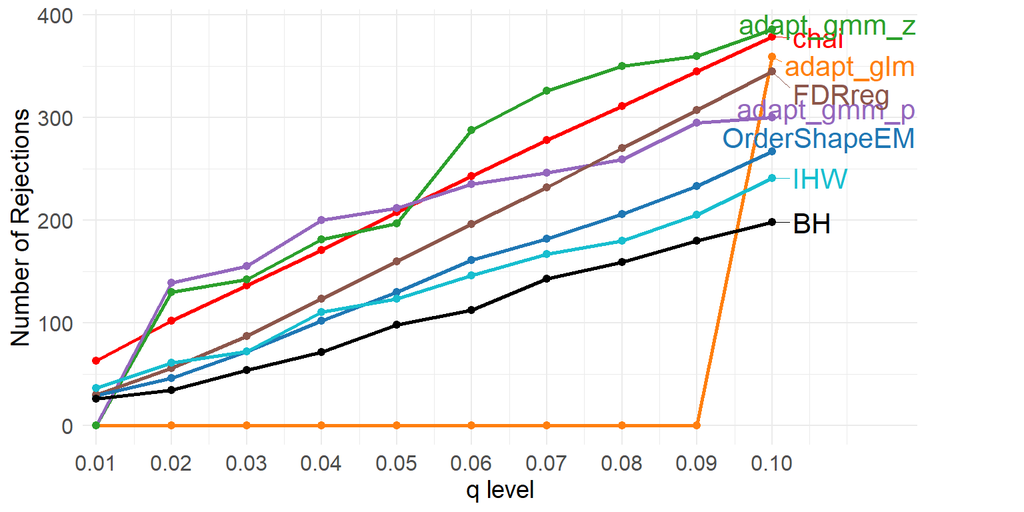

```r
p_eraw_cca
```

Scatter plot of z-value vs Canonical Correlation coefficient.

```r
# chai selections at 0.05 FDR level
chai_sel <- clfdrselect(chai_cca$clFDR, 0.05, 1)

# BH selections at 0.05 FDR level
p_adjusted <- p.adjust(p_value, method = "BH")
bh <- which(p_adjusted <= 0.05)

df <- data.frame(z = z_value, x = cancor) %>%
  dplyr::mutate(
    grp = dplyr::case_when(
      dplyr::row_number() %in% bh & dplyr::row_number() %in% chai_sel ~ "both",
      dplyr::row_number() %in% bh ~ "BH_only",
      dplyr::row_number() %in% chai_sel ~ "chai_only",
      TRUE ~ "neither"
    )
  )

cca_sel <- ggplot(df, aes(x = z, y = x, color = grp)) +
  geom_point(alpha = 0.4) +
  scale_color_manual(
    values = c(
    chai_only  = "red",
    BH_only  = "blue",
    both    = "green",
    neither = "black"
    ),
    breaks = c("chai_only", "BH_only", "both", "neither"),
    labels = c("Only in chai", "Only in BH", "In both", "Neither")
    ) +
  labs(# title = "z-statistics vs CCA coefficient",
       x = "z-value",
       y = "Canonical Correlation",
       color = "Group") +
  theme_minimal() +
  theme(
    plot.margin = margin(5.5, 60, 5.5, 5.5),
    axis.title.x = element_text(size = 14),
    axis.title.y = element_text(size = 14),
    axis.text.x  = element_text(size = 12),
    axis.text.y  = element_text(size = 12),
    legend.title = element_text(size = 14),
    legend.text  = element_text(size = 12)
  )
```

```r
design <- "AAAAAAABBBB"

Eraw_comb <- p_eraw_cca  + cca_sel +
  plot_layout(design = design) +
  plot_annotation(tag_levels = "A") +
  theme(
    # Justify the legend to the right and center it vertically
    legend.justification = c(1, 0.5),
    # Remove extra padding around the legend box
    legend.box.margin = margin(0, 0, 0, 0),
    # Optional: reduce plot margins on the right side
    plot.margin = margin(t = 5, r = 0, b = 5, l = 5)
  )
```

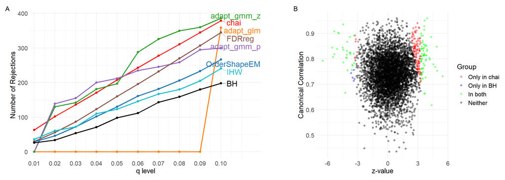

```r
Eraw_comb
```